# Sacred values as index signals of trustworthy character — Reproducibility Pipeline (Study 3)

Reproduction of the incentivized trust-game results for Study 3, in the main text and the Supporting Information

August 2026

# 1 What this document is

Study 3 is the **incentivized lab trust game**: it tests whether perceived trustworthiness translates into *trusting behavior with real money*, and whether that trust is *warranted* — whether sacred valuers actually return more when they could defect.

This pipeline reproduces, from the archived data, **every statistical test reported for Study 3 — in both the main text and the Supporting Information (SI)** — and audits each computed value against the number printed in the manuscript. It follows the same push-button standard as the other pipelines.

**Preregistration and analysis code.** The OSF archive contains the *preregistered* Stata analysis (`hypothesis 1/2/3 *.do`: OLS, rank-sum, mixed logit). As disclosed in the manuscript, the paper departs from the preregistered investor specification (the raw revealed count) in favor of the categorical test that better fits the index-signal account; both the preregistered count model and the categorical test are reproduced here. A port of the preregistered OLS specifications is included in an appendix below.

# 2 Setup

```r
suppressPackageStartupMessages({
  library(haven)    # read Stata .dta
  library(dplyr)    # data manipulation
  library(mgcv)     # generalized additive models
  library(lme4)     # mixed logistic regression (Stata melogit equivalent)
  library(coin)     # Mann-Whitney with the exact standardized Z
  library(ggplot2)  # figures
  library(tibble)
  library(knitr)
})
set.seed(20260619)
```

```r
find_data_root <- function(start = getwd(), marker = "data") {
  d <- normalizePath(start, winslash = "/", mustWork = FALSE)
  repeat {
    if (dir.exists(file.path(d, marker))) return(d)
    parent <- dirname(d)
    if (identical(parent, d))
      stop("Could not locate the 'data' directory from ", start, call. = FALSE)
    d <- parent
  }
}

PROJECT_ROOT <- find_data_root()

# Report paths relative to the project root, so the knitted HTML carries no
# machine-specific absolute path. Anything outside the root prints as its
# basename only.
rel_to_root <- function(path, root = PROJECT_ROOT) {
  path <- normalizePath(path, winslash = "/", mustWork = FALSE)
  root <- normalizePath(root, winslash = "/", mustWork = FALSE)
  if (startsWith(path, root)) {
    file.path("<project root>", sub("^/", "", substring(path, nchar(root) + 1L)))
  } else {
    basename(path)
  }
}

S3_DIR <- file.path(PROJECT_ROOT, "data", "Study 3 - Lab Study",
                    "Replication Documentation", "Data", "Analysis Data")
s3_file <- file.path(S3_DIR, "combined-ult-trust-withfactors.dta")
stopifnot("Study 3 analysis .dta not found" = file.exists(s3_file))
cat("Study 3 data:\n  ", rel_to_root(s3_file), "\n")
```

```
## Study 3 data:
##    <project root>/data/Study 3 - Lab Study/Replication Documentation/Data/Analysis Data/combined-ult-trust-withfactors.dta
```

## 2.1 Helper functions

```r
# Pearson correlation, reported the way the paper does ---------------------------
pearson_report <- function(x, y) {
  ok <- stats::complete.cases(x, y)
  ct <- suppressWarnings(stats::cor.test(x[ok], y[ok], method = "pearson"))
  list(r = unname(ct$estimate), p = ct$p.value, n = sum(ok))
}

# Common-language effect size ----------------------------------------------------
# P(a random value from the group coded 1 exceeds a random value from group 0),
# ties counted as one half -- the same statistic the vignette studies report.
cles <- function(x, g) {
  a <- x[g == 1 & !is.na(x)]; b <- x[g == 0 & !is.na(x)]
  mean(outer(a, b, function(u, v) (u > v) + 0.5 * (u == v)))
}

# Pull the smooth-term F, p, edf from a fitted mgcv::gam ------------------------
# edf (effective degrees of freedom) is the diagnostic for non-linearity: edf ~ 1
# means the smooth is effectively a straight line (the GAM only *relaxed* linearity,
# it did not find curvature); edf materially > 1 means genuine curvature.
gam_smooth <- function(fit) {
  s  <- summary(fit)
  st <- s$s.table[1, ]
  list(F = unname(st["F"]), p = unname(st["p-value"]), edf = unname(st["edf"]),
       n = s$n, r2 = s$r.sq)
}

# Reported one-SD effect: predicted change in the outcome for a one-SD increase in the
# focal predictor, every covariate held at its mean. This is the "B" the manuscript
# reports (e.g. the +8 pp/SD trust effect). ------------------------------------------
gam_oneSD <- function(fit, xvar) {
  md    <- fit$model                       # model frame: response first, then predictors
  preds <- setdiff(names(md), names(md)[1])
  mk <- function(xval) as.data.frame(setNames(
    lapply(preds, function(p) if (p == xvar) xval else mean(md[[p]], na.rm = TRUE)), preds))
  mu <- mean(md[[xvar]], na.rm = TRUE); s <- sd(md[[xvar]], na.rm = TRUE)
  unname(predict(fit, mk(mu + s)) - predict(fit, mk(mu)))
}

# One audit row: computed vs the value the manuscript reports ------------------
audit_row <- function(quantity, computed, claimed, tol, digits = 2) {
  fmt <- function(v) if (is.na(v)) "--" else formatC(v, format = "f", digits = digits)
  check <- if (is.na(claimed)) "descriptive"
           else { d <- abs(computed - claimed)
                  if (d <= tol) "match" else if (d <= 3 * tol) "close" else "DIFFERS" }
  tibble(Quantity = quantity, Reported = fmt(claimed), Computed = fmt(computed), Check = check)
}
```

## 2.2 Load and prepare

```r
raw <- read_dta(s3_file)

# --- Revealed-similarity ("self-similarity") factors --------------------------------
# Reconstructs `hypothesis 2 code.do`: min-max normalize the three sacred-inventory
# factor scores (full inventory and revealed-only), weight the revealed scores by the
# number of statements the trustee revealed, then for each trustee take the negated
# Euclidean distance between the investor partner's full-inventory score and the
# trustee's weighted revealed score. Higher `wsim` = investor and trustee look more
# similar on that factor. Built **once** here so both the controlled models and the
# preregistered OLS port (H2, appendix) consume a single construction.
nrm <- function(x) { r <- range(x, na.rm = TRUE); (x - r[1]) / (r[2] - r[1]) }
full <- raw                                   # normalize over the full archive, per the .do order
for (i in 1:3) {
  full[[paste0("f", i, "n")]]  <- nrm(full[[paste0("full_f", i)]])
  full[[paste0("r", i, "n")]]  <- nrm(full[[paste0("rev_f", i)]])
  full[[paste0("r", i, "n2")]] <- full[[paste0("r", i, "n")]] / full$NumRev
}
full <- full %>% filter(as_factor(treatment) == "trust") %>%   # trust game only (drop ultimatum arm)
  group_by(t3groups) %>%
  mutate(pf1 = sum(f1n * (role_a_b == 1), na.rm = TRUE),        # investor partner's factor score
         pf2 = sum(f2n * (role_a_b == 1), na.rm = TRUE),
         pf3 = sum(f3n * (role_a_b == 1), na.rm = TRUE)) %>%
  ungroup()
for (i in 1:3)                                                 # revealed similarity = -|partner - revealed|
  full[[paste0("wsim", i)]] <- -sqrt((full[[paste0("pf", i)]] - full[[paste0("r", i, "n2")]])^2)

# Roles: 1 = investor, 2 = trustee (per the OSF .do files).
investors <- full %>% filter(role_a_b == 1)
trustees  <- full %>% filter(role_a_b == 2)

cat(sprintf("Trust-game rows: %d  (investors %d, trustees %d = %d complete dyads)\n",
            nrow(full), nrow(investors), nrow(trustees), nrow(trustees)))
```

```
## Trust-game rows: 242  (investors 121, trustees 121 = 121 complete dyads)
```

```r
cat("Archived sample = 242 participants = 121 complete dyads; matches the manuscript N = 242.\n")
```

```
## Archived sample = 242 participants = 121 complete dyads; matches the manuscript N = 242.
```

```r
# Confirm the dyads are intact (equal investor / trustee counts).
stopifnot("unexpected role imbalance (broken dyads)" = nrow(investors) == nrow(trustees))
```

Key variables (from the OSF data and `.do` files):

- `Tru_diff` — investor trust: change in amount transferred between Trust Games 2 and 1.
- `Wor_agg_avg` — trustworthiness: average proportion returned across Games 1 and 2.
- `SacPers` — sacred values *held*: endorsed in the Phase-1 inventory.
- `SacRev` — sacred values *revealed* (count) by the trustee.
- `NetRev` = `SacRev - NonSacRev` — net (balance of) sacred values revealed by the trustee.
- `partnerNetRev` — the trustee partner’s `NetRev`, as seen by the investor.
- `wsim1/wsim2/wsim3` — revealed self-similarity on three factors (built in prep; see above).
- `Greed` — control.

# 3 Main-text results

## 3.1 Warranted trustworthiness (Figure 2)

```r
# Warranted trust (Fig 2): trustees who hold more sacred values return more.
s3_return <- pearson_report(trustees$Wor_agg_avg, trustees$SacPers)
# Continuous investor association (net balance revealed) -- an SI result, kept here as a
# descriptive cross-reference to the primary categorical test below.
s3_invest <- pearson_report(investors$Tru_diff, investors$partnerNetRev)

cat(sprintf("Fig 2  trustworthiness ~ sacred values held  : r = %.3f, p = %.5f (n = %d)\n",
            s3_return$r, s3_return$p, s3_return$n))
```

```
## Fig 2  trustworthiness ~ sacred values held  : r = 0.344, p = 0.00011 (n = 121)
```

```r
cat(sprintf("(SI)   investor trust ~ net values revealed  : r = %.3f, p = %.4f (n = %d)\n",
            s3_invest$r, s3_invest$p, s3_invest$n))
```

```
## (SI)   investor trust ~ net values revealed  : r = 0.232, p = 0.0105 (n = 121)
```

**Percentage-point interpretation.** The manuscript reports the trustworthiness effect as **+0.31 percentage points** of the stake returned per sacred value held, and **+5.7 points** across a one-standard-deviation increase. `Wor_agg_avg` is the proportion returned, so the linear `SacPers` slope times 100 is the pp figure.

```r
b_sp  <- coef(lm(Wor_agg_avg ~ SacPers, data = trustees))["SacPers"]
sd_sp <- sd(trustees$SacPers, na.rm = TRUE)
cat(sprintf("Trustworthiness: +%.2f pp per sacred value held; +%.1f pp per 1 SD (%.1f values); p = %.5f.\n",
            100 * b_sp, 100 * b_sp * sd_sp, sd_sp,
            summary(lm(Wor_agg_avg ~ SacPers, data = trustees))$coefficients["SacPers", "Pr(>|t|)"]))
```

```
## Trustworthiness: +0.31 pp per sacred value held; +5.7 pp per 1 SD (18.3 values); p = 0.00011.
```

The reproduction figure is a **single trustworthiness panel** matching the manuscript’s Figure 2: the penalized GAM (k = 3) of proportion returned on sacred values held, raw scatter removed and the vertical axis zoomed to the fitted curve and its 95% band, so the band’s departure from the flat no-effect line is legible. The manuscript PDF is produced by the script `scripts/R/study3_partials_figure.R` (`Figures/study3_trustgame_partials.pdf`); this reproduces the same smooth.

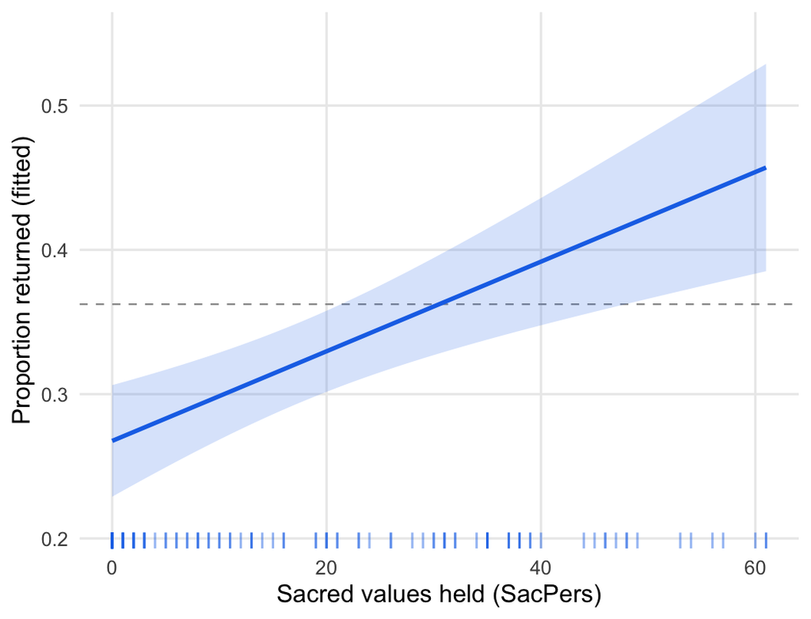

Study 3, Figure 2 (single panel). Penalized GAM fit (k = 3, REML) of the proportion returned on the trustee’s own sacred values held, with the raw scatter removed and the vertical axis zoomed. Line is the GAM fit; shaded band is the 95% CI; dashed line is the no-effect reference; tick marks show observed values held.

```r
# Manuscript Figure 2: stiff (k = 3) GAM partial fit of trustworthiness on values held,
# scatter removed and axis zoomed. Same smooth-only model as the trustworthiness GAM below.
gfig_worthy <- gam(Wor_agg_avg ~ s(SacPers, k = 3), data = trustees, method = "REML")

band_fig <- function(fit, xvar, n = 200) {
  x  <- fit$model[[xvar]]
  gx <- seq(min(x, na.rm = TRUE), max(x, na.rm = TRUE), length.out = n)
  pr <- predict(fit, setNames(data.frame(gx), xvar), se.fit = TRUE)
  data.frame(x = gx, fit = pr$fit,
             lwr = pr$fit - 1.96 * pr$se.fit, upr = pr$fit + 1.96 * pr$se.fit)
}
fig_df <- band_fig(gfig_worthy, "SacPers")
rug_df <- data.frame(x = gfig_worthy$model$SacPers)

ggplot(fig_df, aes(x, fit)) +
  geom_hline(yintercept = mean(fig_df$fit), linetype = "dashed",
             colour = "grey60", linewidth = 0.4) +
  geom_ribbon(aes(ymin = lwr, ymax = upr), fill = "#1a73e8", alpha = 0.18) +
  geom_line(colour = "#1a73e8", linewidth = 1) +
  geom_rug(data = rug_df, aes(x = x), inherit.aes = FALSE, sides = "b",
           colour = "#1a73e8", alpha = 0.45) +
  scale_y_continuous(expand = expansion(mult = 0.12)) +
  labs(x = "Sacred values held (SacPers)", y = "Proportion returned (fitted)") +
  theme_minimal(base_size = 12) +
  theme(panel.grid.minor = element_blank())
```

## 3.2 The investor signal: a categorical (binary) test

The primary investor result. On the index-signal account a revealed sacred value discloses a *capacity* — the ability to internalize a moral rule at all — so the diagnostic contrast is categorical: did the trustee reveal **any** sacred value (`SacRev > 0`), or only tradeable ones? Every trustee revealed at least two statements, so the `SacRev == 0` group genuinely revealed at least two non-sacred values. This reproduces the main-text paragraph and SI `sec:s3-binary`; the source of these numbers is `explorations/study3_netrev_decomposition/` and the figure script `scripts/R/study3_investor_binary_violin.R`.

```r
trustees <- trustees %>% mutate(any_sacred = as.integer(SacRev > 0))
n_trad <- sum(trustees$any_sacred == 0)   # revealed only tradeable values
n_sac  <- sum(trustees$any_sacred == 1)   # revealed >= 1 sacred value

# Group means of the change in trust (Tru_diff).
bin_means <- tapply(trustees$Tru_diff, trustees$any_sacred, mean, na.rm = TRUE)

# Headline contrast.
m_bin    <- lm(Tru_diff ~ any_sacred, data = trustees)
bin_b    <- coef(m_bin)["any_sacred"]
bin_p    <- summary(m_bin)$coefficients["any_sacred", "Pr(>|t|)"]
bin_r2   <- summary(m_bin)$r.squared
bin_cles <- cles(trustees$Tru_diff, trustees$any_sacred)

# Robust to controls (revealed self-similarity + dispositional greed; no age/sex,
# which have no theoretical warrant here).
m_binc  <- lm(Tru_diff ~ any_sacred + wsim1 + wsim2 + wsim3 + Greed, data = trustees)
binc_b  <- coef(m_binc)["any_sacred"]
binc_p  <- summary(m_binc)$coefficients["any_sacred", "Pr(>|t|)"]

# Confirm a sacred-value threshold rather than a penalty on non-sacred revelations:
# hold the non-sacred count (and total revealed) fixed and the threshold still moves trust.
m_binn  <- lm(Tru_diff ~ any_sacred + NonSacRev, data = trustees)
binn_b  <- coef(m_binn)["any_sacred"]
binn_p  <- summary(m_binn)$coefficients["any_sacred", "Pr(>|t|)"]
binn_np <- summary(m_binn)$coefficients["NonSacRev",  "Pr(>|t|)"]
m_binnn <- lm(Tru_diff ~ any_sacred + NonSacRev + NumRev, data = trustees)
binnn_b <- coef(m_binnn)["any_sacred"]
binnn_p <- summary(m_binnn)$coefficients["any_sacred", "Pr(>|t|)"]

# Convergence on stated beliefs: same split predicts the trustee's belief the partner
# will trust them more.
m_binbel <- lm(as.numeric(blf_trustee_trust) ~ any_sacred, data = trustees)
binbel_b <- coef(m_binbel)["any_sacred"]
binbel_p <- summary(m_binbel)$coefficients["any_sacred", "Pr(>|t|)"]

cat(sprintf("Groups: only-tradeable n = %d (mean Tru_diff %.3f) | some-sacred n = %d (mean %.3f)\n",
            n_trad, bin_means["0"], n_sac, bin_means["1"]))
```

```
## Groups: only-tradeable n = 56 (mean Tru_diff -0.223) | some-sacred n = 65 (mean -0.027)
```

```r
cat(sprintf("Binary contrast   : b = %.3f, p = %.4f, CLES = %.3f, R^2 = %.3f\n",
            bin_b, bin_p, bin_cles, bin_r2))
```

```
## Binary contrast   : b = 0.196, p = 0.0016, CLES = 0.646, R^2 = 0.081
```

```r
cat(sprintf("  + controls      : b = %.3f, p = %.4f  (self-similarity + greed)\n", binc_b, binc_p))
```

```
##   + controls      : b = 0.167, p = 0.0104  (self-similarity + greed)
```

```r
cat(sprintf("  + NonSacRev     : b = %.3f, p = %.4f  (NonSacRev p = %.3f, null)\n", binn_b, binn_p, binn_np))
```

```
##   + NonSacRev     : b = 0.153, p = 0.0277  (NonSacRev p = 0.178, null)
```

```r
cat(sprintf("  + NonSacRev+Num : b = %.3f, p = %.4f\n", binnn_b, binnn_p))
```

```
##   + NonSacRev+Num : b = 0.196, p = 0.0185
```

```r
cat(sprintf("On belief 'partner trusts more' : b = %.3f, p = %.6f\n", binbel_b, binbel_p))
```

```
## On belief 'partner trusts more' : b = 0.965, p = 0.000009
```

**Reading the result.** The split is well balanced (56 only-tradeable, 65 some-sacred). Trust held roughly steady toward the some-sacred group (mean change ≈ -0.03) and was withdrawn from the only-tradeable group (≈ -0.22) — a gap of about 20 percentage points of the endowment (b = .196, p = .002, CLES = .65), accounting for about 8% of the variance. It survives controls for self-similarity and greed (b = .167, p = .01) where the continuous `NetRev` fit decays to marginal, and it reflects a sacred-value threshold rather than a penalty on non-sacred revelations: holding the non-sacred count fixed, crossing the sacred threshold still raises trust (p = .028) while the non-sacred count goes null. The same split predicts the trustee’s belief that the partner will trust them more.

## 3.3 The trustee side

The mirror check the main text cites: binarizing the trustworthiness predictor into *any* sacred value held versus none does **not** on its own predict trustworthiness — the warranted-trust side is better described by a dose-response, and the continuous count subsumes the binary. This is why the paper reports the investor side categorically and the trustee side continuously.

```r
trustees <- trustees %>% mutate(any_held = as.integer(SacPers > 0))
n_held0 <- sum(trustees$any_held == 0)   # holds no sacred value
n_held1 <- sum(trustees$any_held == 1)   # holds >= 1

tb      <- lm(Wor_agg_avg ~ any_held, data = trustees)
tb_b    <- coef(tb)["any_held"]
tb_p    <- summary(tb)$coefficients["any_held", "Pr(>|t|)"]
tb_cles <- cles(trustees$Wor_agg_avg, trustees$any_held)
tbc_p   <- summary(lm(Wor_agg_avg ~ any_held + Greed, data = trustees))$coefficients["any_held", "Pr(>|t|)"]

# Head-to-head: continuous count against the binary. Count survives, binary collapses.
tb_h2h   <- lm(Wor_agg_avg ~ any_held + SacPers, data = trustees)
tb_h2h_p <- summary(tb_h2h)$coefficients["any_held", "Pr(>|t|)"]
tb_sp_p  <- summary(tb_h2h)$coefficients["SacPers",  "Pr(>|t|)"]
add_sp_F <- anova(lm(Wor_agg_avg ~ any_held, data = trustees), tb_h2h)$F[2]  # adding count to binary
add_ah_F <- anova(lm(Wor_agg_avg ~ SacPers,  data = trustees), tb_h2h)$F[2]  # adding binary to count

# Median split (SI sec:s3-binary): the zero cut is low-powered because the held-none group is
# small (31) and the signal is spread across the whole 0-61 range. Cutting at the MEDIAN values
# held instead yields balanced groups and recovers the graded effect -- but it is still just a
# coarse proxy for the continuous count, not evidence of a categorical threshold.
med_held <- median(trustees$SacPers, na.rm = TRUE)
trustees <- trustees %>% mutate(hi_held = as.integer(SacPers >= med_held))
n_lo <- sum(trustees$hi_held == 0); n_hi <- sum(trustees$hi_held == 1)
mb      <- lm(Wor_agg_avg ~ hi_held, data = trustees)
mb_b    <- coef(mb)["hi_held"]
mb_p    <- summary(mb)$coefficients["hi_held", "Pr(>|t|)"]
mb_cles <- cles(trustees$Wor_agg_avg, trustees$hi_held)
mb_r2   <- summary(mb)$r.squared
mbc_p   <- summary(lm(Wor_agg_avg ~ hi_held + Greed, data = trustees))$coefficients["hi_held", "Pr(>|t|)"]
# Head-to-head: median split against the continuous count -- neither dominates (both proxy one gradient).
mb_h2h   <- lm(Wor_agg_avg ~ hi_held + SacPers, data = trustees)
mb_h2h_p <- summary(mb_h2h)$coefficients["hi_held", "Pr(>|t|)"]
mb_sp_p  <- summary(mb_h2h)$coefficients["SacPers", "Pr(>|t|)"]

cat(sprintf("Held none n = %d | holds >=1 n = %d\n", n_held0, n_held1))
```

```
## Held none n = 31 | holds >=1 n = 90
```

```r
cat(sprintf("Binary held>0 : b = %.3f (%.1f pp), p = %.3f, CLES = %.3f; + greed p = %.3f\n",
            tb_b, 100 * tb_b, tb_p, tb_cles, tbc_p))
```

```
## Binary held>0 : b = 0.064 (6.4 pp), p = 0.064, CLES = 0.593; + greed p = 0.150
```

```r
cat(sprintf("Head-to-head  : any_held p = %.3f (null), SacPers p = %.4f (survives)\n", tb_h2h_p, tb_sp_p))
```

```
## Head-to-head  : any_held p = 0.727 (null), SacPers p = 0.0007 (survives)
```

```r
cat(sprintf("Nested F      : adding count to binary F = %.2f; adding binary to count F = %.2f\n",
            add_sp_F, add_ah_F))
```

```
## Nested F      : adding count to binary F = 12.10; adding binary to count F = 0.12
```

```r
cat(sprintf("Median split (>= %g held): low n = %d | high n = %d\n", med_held, n_lo, n_hi))
```

```
## Median split (>= 11 held): low n = 60 | high n = 61
```

```r
cat(sprintf("Median split  : b = %.3f (%.1f pp), p = %.4f, CLES = %.3f, R^2 = %.3f; + greed p = %.4f\n",
            mb_b, 100 * mb_b, mb_p, mb_cles, mb_r2, mbc_p))
```

```
## Median split  : b = 0.109 (10.9 pp), p = 0.0002, CLES = 0.683, R^2 = 0.109; + greed p = 0.0020
```

```r
cat(sprintf("  h2h vs count: median-split p = %.3f, SacPers p = %.3f (neither dominates; one gradient)\n",
            mb_h2h_p, mb_sp_p))
```

```
##   h2h vs count: median-split p = 0.366, SacPers p = 0.157 (neither dominates; one gradient)
```

**Reading the result.** Dichotomizing the trustee side *at zero* is marginal alone (+6.4 pp, CLES = .59, p = .06), null under controls (p = .15), and the continuous count fully subsumes it (adding the count to the binary: F ≈ 12, p < .001; adding the binary to the count: F ≈ 0.1, p = .73). The trustee side is genuinely graded — the reception-vs-trait asymmetry the manuscript describes. The zero-cut null is a matter of power, not of the underlying relationship: only 31 of 121 trustees held no sacred value, so the cut isolates a small, atypical group and discards the gradient in between. Cutting at the **median** (11 values held) instead gives balanced groups (60 vs 61) and recovers a clear contrast (+10.9 pp, p < .001, CLES = .68, R² = .11) that survives the greed control (p = .002). But that is not a categorical threshold: entered against the continuous count neither dominates (median split p = .37, count p = .16), so the median contrast appears to be a coarse proxy for the one underlying gradient.

# 4 SI results

## 4.1 Trustworthiness holds within each trust game (`sec:s3-pergame`)

Figure 2 regresses the trustee’s return **averaged across both trust games** — `Wor_agg_avg` is the mean of `Wor_pre_avg` (the Phase-1 baseline game, played before the sacred-value elicitation) and `Wor_post_avg` (the Phase-3 game, after the trustee’s partial revelation). Averaging is a noise-reduction move: the two games are two reads on one standing disposition (they correlate at *r* ≈ .77), so the mean is the more reliable estimate. The same dose-response is present in each game on its own, at similar magnitude. The cleanest case is the Phase-1 baseline, played *before* the elicitation even occurred: values held still predict returns there.

```r
# Per-game components of Wor_agg_avg: Wor_pre_avg = Game 1 (Phase-1 baseline),
# Wor_post_avg = Game 2 (Phase-3, after revelation). Confirm the pooled measure is their mean.
stopifnot("Wor_agg_avg is not the mean of the two per-game measures" =
          max(abs(trustees$Wor_agg_avg -
                  (trustees$Wor_pre_avg + trustees$Wor_post_avg) / 2), na.rm = TRUE) < 1e-6)
rel <- cor(trustees$Wor_pre_avg, trustees$Wor_post_avg, use = "complete.obs")

# Linear + GAM report of a per-game outcome on SacPers (values held).
pg <- function(dv) {
  ok  <- stats::complete.cases(trustees[[dv]], trustees$SacPers)
  d   <- data.frame(y = trustees[[dv]][ok], SacPers = trustees$SacPers[ok])
  lm1 <- lm(y ~ SacPers, data = d)
  b   <- coef(lm1)["SacPers"]
  g   <- gam(y ~ s(SacPers, k = 3), data = d, method = "REML")
  c(r    = unname(cor(d$y, d$SacPers)),
    pp   = unname(100 * b),
    ppSD = unname(100 * b * sd(d$SacPers)),
    p    = summary(lm1)$coefficients["SacPers", "Pr(>|t|)"],
    R2   = summary(lm1)$r.squared,
    edf  = unname(summary(g)$s.table[1, "edf"]))
}
pg_tab <- rbind(`Both games (Fig 2)`  = pg("Wor_agg_avg"),
                `Game 1 (baseline)`   = pg("Wor_pre_avg"),
                `Game 2 (revelation)` = pg("Wor_post_avg"))

cat(sprintf("Between-game reliability: cor(Game 1, Game 2 return) = %.3f\n\n", rel))
```

```
## Between-game reliability: cor(Game 1, Game 2 return) = 0.774
```

```r
print(round(pg_tab, 3))
```

```
##                         r    pp  ppSD     p    R2 edf
## Both games (Fig 2)  0.344 0.311 5.696 0.000 0.118   1
## Game 1 (baseline)   0.296 0.276 5.053 0.001 0.087   1
## Game 2 (revelation) 0.350 0.346 6.338 0.000 0.122   1
```

## 4.2 Continuous net-balance fit and controls (`sec:s3-continuous`)

The continuous companion to the categorical main-text test. DV = investor trust (`Tru_diff`); penalized smooth on the balance of sacred vs non-sacred values the trustee revealed (`NetRev`).  
The SI reports the smooth as effectively linear (edf ≈ 1), smooth F = 5.42, p = .024, with a one-SD increase in the net balance worth about +8 pp of the endowment; the association holds controlling separately for self-similarity (p = .032) and greed (p = .027) and weakens to marginal under both controls jointly (p = .069). The categorical test above is the more robust to controls.

Run on the **trustee frame** with `NetRev`, faithful to the archived `regress Tru_diff NetRev ... if role_a_b == 2`. Model 1 is numerically identical to a smooth on `partnerNetRev` over the investor frame — the same dyads, with the trustee’s net revealed values stored on the trustee row (`NetRev`) rather than the investor row (`partnerNetRev`).

```r
g4_m1 <- gam(Tru_diff ~ s(NetRev, k = 3),
             data = trustees, method = "REML")
g4_m2 <- gam(Tru_diff ~ s(NetRev, k = 3) + wsim1 + wsim2 + wsim3,
             data = trustees, method = "REML")

t4 <- bind_rows(
  data.frame(Model = "1: smooth only",            as.data.frame(gam_smooth(g4_m1))),
  data.frame(Model = "2: + self-similarity",      as.data.frame(gam_smooth(g4_m2)))
)
kable(t4, digits = 3,
      caption = "Continuous net-balance fit (SI sec:s3-continuous) --- investor trust on the trustee's net sacred values revealed. `edf` is the smooth's effective degrees of freedom (≈1 ⇒ effectively linear). Model 1 is the smooth the SI reports (F = 5.42, p = .024); the self-similarity-controlled model is shown for completeness.")
```

Continuous net-balance fit (SI sec:s3-continuous) — investor trust on the trustee’s net sacred values revealed. `edf` is the smooth’s effective degrees of freedom (≈1 ⇒ effectively linear). Model 1 is the smooth the SI reports (F = 5.42, p = .024); the self-similarity-controlled model is shown for completeness.

| Model | F | p | edf | n | r2 |
| --- | --- | --- | --- | --- | --- |
| 1: smooth only | 5.418 | 0.024 | 1.308 | 121 | 0.049 |
| 2: + self-similarity | 3.905 | 0.062 | 1.372 | 121 | 0.051 |

**Percentage-point interpretation and controls.** `Tru_diff` is the change in the *share* of the (4-unit) endowment transferred, so the linear `NetRev` slope (SI alt-specs col. 4) times 100 is the pp figure, and the one-SD *B* below is on the same scale. The control p-values are the OLS `NetRev` coefficient with each control set added, matching the SI’s .032 / .027 / .069.

```r
b_net  <- coef(lm(Tru_diff ~ NetRev, data = trustees))["NetRev"]
sd_net <- sd(trustees$NetRev, na.rm = TRUE)
cat(sprintf("Trust: +%.2f pp of endowment per net value revealed; +%.1f pp per 1 SD (%.1f values).\n",
            100 * b_net, 100 * b_net * sd_net, sd_net))
```

```
## Trust: +0.85 pp of endowment per net value revealed; +8.0 pp per 1 SD (9.4 values).
```

```r
ctrl <- function(f) { co <- summary(lm(f, data = trustees))$coefficients["NetRev", ]
  sprintf("b = %.4f, p = %.3f", co["Estimate"], co["Pr(>|t|)"]) }
cat("  + self-similarity :", ctrl(Tru_diff ~ NetRev + wsim1 + wsim2 + wsim3),          "(SI p = .032)\n")
```

```
##   + self-similarity : b = 0.0073, p = 0.031 (SI p = .032)
```

```r
cat("  + greed           :", ctrl(Tru_diff ~ NetRev + Greed),                          "(SI p = .027)\n")
```

```
##   + greed           : b = 0.0077, p = 0.027 (SI p = .027)
```

```r
cat("  + both jointly    :", ctrl(Tru_diff ~ NetRev + wsim1 + wsim2 + wsim3 + Greed),  "(SI p = .069)\n")
```

```
##   + both jointly    : b = 0.0064, p = 0.069 (SI p = .069)
```

## 4.3 SI alternative specifications (`s3-alt-specs`) — OLS specifications of investor trust

The SI’s *Alternative specifications of regression model for trustworthiness* (table `s3-alt-specs`) reports five plain-OLS specifications of the same dependent variable — the change in investor trust between games (`Tru_diff`, the SI’s “ΔTrust”) — on different summaries of what the trustee revealed. These are the straight-line companions to the continuous NetRev smooth above. The two that carry the headline signaling result at *p* < .05 are column (4), trust on the **net** balance revealed (`NetRev` = sacred − non-sacred), and column (5), the same with `Greed` partialled out. The originally planned `SacRev`-only model is column (1) — the weakest specification, as the SI notes. All five are run on the trustee frame (`role_a_b == 2`), faithful to the archived `regress Tru_diff ... if role_a_b == 2`.

```r
# Five OLS specifications of investor trust change (Tru_diff = ΔTrust) on what the trustee
# revealed -- the linear-model companions to the continuous NetRev GAM. Cols match SI s3-alt-specs:
# (1) SacRev; (2) SacRev + total revealed (NumRev); (3) NonSacRev; (4) NetRev; (5) NetRev + Greed.
t7_specs <- list(
  "(1) SacRev"                  = Tru_diff ~ SacRev,
  "(2) SacRev + total revealed" = Tru_diff ~ SacRev + NumRev,
  "(3) NonSacRev"               = Tru_diff ~ NonSacRev,
  "(4) NetRev"                  = Tru_diff ~ NetRev,
  "(5) NetRev + Greed"          = Tru_diff ~ NetRev + Greed
)
t7_fits  <- lapply(t7_specs, function(f) lm(f, data = trustees))

# Tidy table: the focal predictor reported in each published column, with SE, t, p, R^2, N.
t7_focal <- c("SacRev", "SacRev", "NonSacRev", "NetRev", "NetRev")
t7_tab <- bind_rows(Map(function(fit, nm, foc) {
  co <- summary(fit)$coefficients
  data.frame(Model = nm, Focal = foc,
             b = co[foc, "Estimate"], SE = co[foc, "Std. Error"],
             t = co[foc, "t value"], p = co[foc, "Pr(>|t|)"],
             R2 = summary(fit)$r.squared, N = length(fit$residuals))
}, t7_fits, names(t7_fits), t7_focal))
kable(t7_tab, digits = c(0, 0, 5, 5, 2, 4, 3, 0),
      caption = "SI table `s3-alt-specs` reproduced --- OLS of investor trust change (Tru_diff) on revealed values. `Focal` is the predictor reported in the published column. Published focal coefficients: (1) .0120, (2) .0158*, (3) -.0140**, (4) .00850*, (5) .00766* (* p < .05, ** p < .01).")
```

SI table `s3-alt-specs` reproduced — OLS of investor trust change (Tru_diff) on revealed values. `Focal` is the predictor reported in the published column. Published focal coefficients: (1) .0120, (2) .0158*, (3) -.0140**, (4) .00850*, (5) .00766* (* p < .05,** p < .01).

| Model | Focal | b | SE | t | p | R2 | N |
| --- | --- | --- | --- | --- | --- | --- | --- |
| (1) SacRev | SacRev | 0.01204 | 0.00655 | 1.84 | 0.0685 | 0.028 | 121 |
| (2) SacRev + total revealed | SacRev | 0.01580 | 0.00675 | 2.34 | 0.0210 | 0.058 | 121 |
| (3) NonSacRev | NonSacRev | -0.01403 | 0.00526 | -2.67 | 0.0086 | 0.057 | 121 |
| (4) NetRev | NetRev | 0.00850 | 0.00327 | 2.60 | 0.0105 | 0.054 | 121 |
| (5) NetRev + Greed | NetRev | 0.00766 | 0.00341 | 2.24 | 0.0267 | 0.060 | 121 |

The audit below checks the five published focal coefficients, plus the auxiliary total-revealed coefficient in column (2), the `Greed` coefficient in column (5), and every column’s *R*², against the printed `s3-alt-specs` values.

```r
foc_b    <- setNames(t7_tab$b, t7_tab$Model)
r2       <- setNames(t7_tab$R2, t7_tab$Model)
t7_greed <- summary(t7_fits[["(5) NetRev + Greed"]])$coefficients["Greed", "Estimate"]
t7_total <- summary(t7_fits[["(2) SacRev + total revealed"]])$coefficients["NumRev", "Estimate"]
t7_audit <- bind_rows(
  audit_row("(1) SacRev coef",         foc_b[["(1) SacRev"]],                  0.0120,  0.001, 4),
  audit_row("(2) SacRev coef",         foc_b[["(2) SacRev + total revealed"]], 0.0158,  0.001, 4),
  audit_row("(2) total-revealed coef", t7_total,                             -0.0125,  0.001, 4),
  audit_row("(3) NonSacRev coef",      foc_b[["(3) NonSacRev"]],              -0.0140,  0.001, 4),
  audit_row("(4) NetRev coef",         foc_b[["(4) NetRev"]],                  0.00850, 0.001, 5),
  audit_row("(5) NetRev coef",         foc_b[["(5) NetRev + Greed"]],          0.00766, 0.001, 5),
  audit_row("(5) Greed coef",          t7_greed,                              -0.174,   0.01,  3),
  audit_row("(1) R^2",                 r2[["(1) SacRev"]],                     0.028,   0.005, 3),
  audit_row("(2) R^2",                 r2[["(2) SacRev + total revealed"]],    0.058,   0.005, 3),
  audit_row("(3) R^2",                 r2[["(3) NonSacRev"]],                  0.057,   0.005, 3),
  audit_row("(4) R^2",                 r2[["(4) NetRev"]],                     0.054,   0.005, 3),
  audit_row("(5) R^2",                 r2[["(5) NetRev + Greed"]],             0.060,   0.005, 3)
)
kable(t7_audit, align = "lrrl")
```

| Quantity | Reported | Computed | Check |
| --- | --- | --- | --- |
| (1) SacRev coef | 0.0120 | 0.0120 | match |
| (2) SacRev coef | 0.0158 | 0.0158 | match |
| (2) total-revealed coef | -0.0125 | -0.0125 | match |
| (3) NonSacRev coef | -0.0140 | -0.0140 | match |
| (4) NetRev coef | 0.00850 | 0.00850 | match |
| (5) NetRev coef | 0.00766 | 0.00766 | match |
| (5) Greed coef | -0.174 | -0.174 | match |
| (1) R^2 | 0.028 | 0.028 | match |
| (2) R^2 | 0.058 | 0.058 | match |
| (3) R^2 | 0.057 | 0.057 | match |
| (4) R^2 | 0.054 | 0.054 | match |
| (5) R^2 | 0.060 | 0.060 | match |

**Reading the result.** All five columns reproduce to the published digits. The two `NetRev` specifications — (4) `NetRev` alone (*b* = .0085, *p* = .011) and (5) `NetRev` + `Greed` (*b* = .0077, *p* = .027) — are both significant at *p* < .05, and `Greed` is far from significant (*p* = .39), so partialling it out leaves the signaling effect intact. The preregistered `SacRev`-only model (1) is the weak one (*p* = .068); switching to the *balance* revealed is what delivers significance and roughly doubles *R*² (.028 → .054).

## 4.4 Trustworthiness GAM (robustness on the Figure 2 smooth)

DV = trustworthiness (`Wor_agg_avg`, proportion returned averaged across games); predictor `SacPers` (values held), the Figure 2 measure. Because edf ≈ 1 the smooth is effectively a straight line, so the GAM and the linear percentage-point coefficient tell the same story.

```r
worthy_pred <- "SacPers"                  # trustworthiness predictor (values held; Figure 2)
fw <- function(rhs) as.formula(sprintf("Wor_agg_avg ~ s(%s, k = 3)%s", worthy_pred, rhs))
g5_m1 <- gam(fw(""),                       data = trustees, method = "REML")

t5 <- data.frame(Model = "1: smooth only (= Figure 2)", as.data.frame(gam_smooth(g5_m1)))
kable(t5, digits = 3,
      caption = "Trustworthiness GAM on SacPers (values held): the Figure 2 smooth. edf ≈ 1 ⇒ effectively linear, so the linear +0.31 pp/value slope the main text reports is the same result.")
```

Trustworthiness GAM on SacPers (values held): the Figure 2 smooth. edf ≈ 1 ⇒ effectively linear, so the linear +0.31 pp/value slope the main text reports is the same result.

| Model | F | p | edf | n | r2 |
| --- | --- | --- | --- | --- | --- |
| 1: smooth only (= Figure 2) | 15.932 | 0 | 1 | 121 | 0.111 |

## 4.5 Are the smooths non-linear? (edf + partial-effect plots)

A GAM’s job is to *relax* the straight-line assumption; whether it found curvature is read off the effective degrees of freedom (`edf`): ≈ 1 means the fitted smooth is essentially a line. Both smooths come back at edf ≈ 1, so the linear coefficients the manuscript reports are adequate.

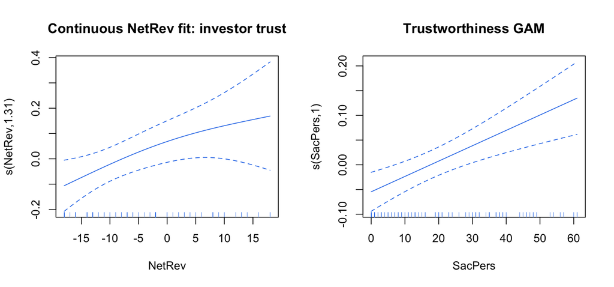

Fitted GAM smooths with 95% confidence bands. Left: investor trust on the trustee’s net sacred values revealed (continuous NetRev fit). Right: trustworthiness on sacred values held.

```r
par(mfrow = c(1, 2))
plot(g4_m1, shade = TRUE, shade.col = "#1a73e833", col = "#1a73e8",
     seWithMean = TRUE, main = "Continuous NetRev fit: investor trust", xlab = "NetRev")
plot(g5_m1, shade = TRUE, shade.col = "#1a73e833", col = "#1a73e8",
     seWithMean = TRUE, main = "Trustworthiness GAM", xlab = worthy_pred)
```

```r
par(mfrow = c(1, 1))

cat(sprintf("Smooth edf -- NetRev fit: %.2f; trustworthiness: %.2f.\n",
            gam_smooth(g4_m1)$edf, gam_smooth(g5_m1)$edf))
```

```
## Smooth edf -- NetRev fit: 1.31; trustworthiness: 1.00.
```

```r
cat("edf near 1 indicates the relationships are effectively linear.\n")
```

```
## edf near 1 indicates the relationships are effectively linear.
```

## 4.6 Reported one-SD effects

For the continuous NetRev fit, the one-SD effect is *B* ≈ .078 — the “+8 percentage points of the endowment per one-SD increase in the net values revealed” the SI reports. Recomputed from the fitted GAMs (predicted outcome change for a one-SD shift, covariates at their means).

```r
b4_m1 <- gam_oneSD(g4_m1, "NetRev")
b5_m1 <- gam_oneSD(g5_m1, worthy_pred)
b_tab <- tibble(
  Quantity = c("Continuous NetRev fit one-SD B", "Trustworthiness M1 one-SD B (SacPers)"),
  Computed = c(b4_m1, b5_m1),
  # SI reports +8 pp/SD (~.078) for the continuous NetRev fit; the other is descriptive.
  Reported = c(0.078, NA))
kable(b_tab, digits = 3, caption = "One-SD predicted effects recomputed from the GAMs. Reported = the manuscript's +8 pp/SD for the continuous NetRev fit; other row descriptive.")
```

One-SD predicted effects recomputed from the GAMs. Reported = the manuscript’s +8 pp/SD for the continuous NetRev fit; other row descriptive.

| Quantity | Computed | Reported |
| --- | --- | --- |
| Continuous NetRev fit one-SD B | 0.077 | 0.078 |
| Trustworthiness M1 one-SD B (SacPers) | 0.057 | NA |

## 4.7 Primary audit (main text + continuous fit)

```r
g4_1 <- gam_smooth(g4_m1)
s3_audit <- bind_rows(
  # Warranted trustworthiness (Figure 2)
  audit_row("Trustworthiness: pp per value held (main text +0.31)", 100 * b_sp,       0.31,  0.03, 2),
  audit_row("Trustworthiness: pp per 1 SD (main text +5.7)",        100 * b_sp * sd_sp, 5.7, 0.3,  1),
  audit_row("Trustworthiness: Pearson r (descriptive)",            s3_return$r,       NA,    0.03, 3),
  # Investor categorical test (primary)
  audit_row("Binary investor: b (SI 0.196; main text ~20 pp)",     bin_b,             0.196, 0.01, 3),
  audit_row("Binary investor: CLES (main text .65)",               bin_cles,          0.65,  0.02, 2),
  audit_row("Binary investor: R^2 (main text ~8%)",                bin_r2,            0.08,  0.02, 3),
  audit_row("Binary investor + controls: b (main text p=.01)",     binc_b,            0.167, 0.01, 3),
  audit_row("Binary investor + NonSacRev: b (SI 0.15)",            binn_b,            0.15,  0.01, 3),
  audit_row("Binary investor + NonSacRev + NumRev: b (SI 0.20)",   binnn_b,           0.20,  0.01, 3),
  audit_row("Binary investor on belief 'trusts more': b (SI 0.97)",binbel_b,          0.97,  0.03, 3),
  # Trustee side is graded (binary null) -- exploration values, descriptive
  audit_row("Trustee binary held>0: b in pp (exploration +6.4)",   100 * tb_b,        NA,    0.5,  1),
  audit_row("Trustee binary: CLES (exploration .59)",              tb_cles,           NA,    0.02, 3),
  # Median split recovers the effect (main text + SI sec:s3-binary)
  audit_row("Trustee median split: b in pp (SI +10.9)",            100 * mb_b,        10.9,  0.5,  1),
  audit_row("Trustee median split: p (SI < .001)",                 mb_p,              NA,    0.001, 4),
  audit_row("Trustee median split: CLES (SI .68)",                 mb_cles,           0.68,  0.02, 2),
  # Continuous fit (SI sec:s3-continuous)
  audit_row("Continuous NetRev smooth F (SI 5.42)",                g4_1$F,            5.42,  0.1),
  audit_row("Continuous NetRev one-SD B (SI +8 pp/SD)",            b4_m1,             0.078, 0.02, 3)
)
kable(s3_audit, align = "lrrl")
```

| Quantity | Reported | Computed | Check |
| --- | --- | --- | --- |
| Trustworthiness: pp per value held (main text +0.31) | 0.31 | 0.31 | match |
| Trustworthiness: pp per 1 SD (main text +5.7) | 5.7 | 5.7 | match |
| Trustworthiness: Pearson r (descriptive) | – | 0.344 | descriptive |
| Binary investor: b (SI 0.196; main text ~20 pp) | 0.196 | 0.196 | match |
| Binary investor: CLES (main text .65) | 0.65 | 0.65 | match |
| Binary investor: R^2 (main text ~8%) | 0.080 | 0.081 | match |
| Binary investor + controls: b (main text p=.01) | 0.167 | 0.167 | match |
| Binary investor + NonSacRev: b (SI 0.15) | 0.150 | 0.153 | match |
| Binary investor + NonSacRev + NumRev: b (SI 0.20) | 0.200 | 0.196 | match |
| Binary investor on belief ‘trusts more’: b (SI 0.97) | 0.970 | 0.965 | match |
| Trustee binary held>0: b in pp (exploration +6.4) | – | 6.4 | descriptive |
| Trustee binary: CLES (exploration .59) | – | 0.593 | descriptive |
| Trustee median split: b in pp (SI +10.9) | 10.9 | 10.9 | match |
| Trustee median split: p (SI < .001) | – | 0.0002 | descriptive |
| Trustee median split: CLES (SI .68) | 0.68 | 0.68 | match |
| Continuous NetRev smooth F (SI 5.42) | 5.42 | 5.42 | match |
| Continuous NetRev one-SD B (SI +8 pp/SD) | 0.078 | 0.077 | match |

**Reading the result.** All manuscript figures reproduce.

> **Note — controls are the trustee’s.** The archived `.do` runs the controlled models `... if role_a_b == 2`, so the dispositional greed control is the trustee’s.

## 4.8 SI-only analyses

> **Scope.** The subsections below reproduce every analysis the paper reports **only in the Supporting Information** for Study 3. Each computed value is collected into the SI audit table at the end of the section.

```r
# Extra archives used only by the SI analyses below.
tc    <- read_dta(file.path(S3_DIR, "trust-combined.dta"))            # 242, trust game
means <- read_dta(file.path(S3_DIR, "combined-ult-trust-means.dta"))  # per-statement endorsement rates
```

## 4.9 Post-game beliefs about trustworthiness and trust (`s3-scatter-belief`, `s3-scatter-trustworthiness`)

After the second trust game but before learning either outcome, participants reported whether they expected their second-game partner to be more or less trusting / trustworthy than their first-game partner. The SI correlates these beliefs against the balance of sacred versus non-sacred values revealed and finds the same pattern as the incentivized behavior:

- **Belief the partner will trust more** (`blf_trustee_trust`, held by the trustee who did the revealing) against the trustee’s own net values revealed (`NetRev`): the strong correlation in `s3-scatter-belief`.
- **Belief the partner will be more trustworthy** (`blf_investor_worthy`, held by the investor) against the balance the trustee partner revealed (`partnerNetRev`): the weaker, marginal correlation in `s3-scatter-trustworthiness`.

```r
belief_trust  <- pearson_report(as.numeric(trustees$blf_trustee_trust),  trustees$NetRev)
belief_worthy <- pearson_report(as.numeric(investors$blf_investor_worthy), investors$partnerNetRev)

cat(sprintf("s3-scatter-belief          belief 'partner trusts more' ~ own NetRev     : r = %.3f, p = %.4f (n = %d)\n",
            belief_trust$r,  belief_trust$p,  belief_trust$n))
```

```
## s3-scatter-belief          belief 'partner trusts more' ~ own NetRev     : r = 0.428, p = 0.0000 (n = 121)
```

```r
cat(sprintf("s3-scatter-trustworthiness belief 'partner worthier'  ~ partner NetRev  : r = %.3f, p = %.4f (n = %d)\n",
            belief_worthy$r, belief_worthy$p, belief_worthy$n))
```

```
## s3-scatter-trustworthiness belief 'partner worthier'  ~ partner NetRev  : r = 0.176, p = 0.0535 (n = 121)
```

## 4.10 Willingness to revise answers (`s3-survey-revision`)

The SI reports that participants holding more sacred values are less inclined to revise their inventory answers. The archived item `survey1playerexp_ques1` (“would give identical answers in future”) runs in the *opposite* direction to “willingness to revise”, so a **positive** correlation with sacred values held (`SacPers`) is the SI’s finding: participants holding more sacred values are more likely to report that they would give identical answers. Defined for all trust-game participants (one is missing the item, so n = 241).

```r
revision <- pearson_report(as.numeric(full$survey1playerexp_ques1), full$SacPers)
cat(sprintf("s3-survey-revision  'would give identical answers' ~ sacred values held : r = %.3f, p = %.5f (n = %d)\n",
            revision$r, revision$p, revision$n))
```

```
## s3-survey-revision  'would give identical answers' ~ sacred values held : r = 0.335, p = 0.00000 (n = 241)
```

## 4.11 The revelation procedure (`sec:s3-revelation-procedure`)

The SI’s revelation-procedure subsection states that a random draw from {0, 2, 5, 9, 16} capped how many of the eighteen rankable statements could be concealed, **so every trustee revealed at least two statements**. That factual claim is checkable against the archived per-trustee revealed count (`NumRev`).

```r
concealed <- 18 - trustees$NumRev
cat("Concealed statements per trustee (18 - NumRev):\n"); print(table(concealed))
```

```
## Concealed statements per trustee (18 - NumRev):
```

```
## concealed
##  0  1  2  4  5  6  7  8  9 11 16
## 42  4 22  2 16  1  3  2 16  1 12
```

```r
cat(sprintf("Revealed range: %d--%d (n = %d trustees)\n",
            min(trustees$NumRev), max(trustees$NumRev), nrow(trustees)))
```

```
## Revealed range: 2--18 (n = 121 trustees)
```

```r
stopifnot("SI claim 'every trustee revealed at least two statements' fails" =
            min(trustees$NumRev, na.rm = TRUE) >= 2,
          "Concealed count exceeds the maximum draw of 16" =
            max(concealed, na.rm = TRUE) <= 16)
# Note: concealed counts need not sit exactly on {0, 2, 5, 9, 16} -- the draw caps how many
# of a trustee's ranked statements are withheld, and trustees could rank fewer than the cap.
```

## 4.12 Did trustees reveal sacred values preferentially? (`s3-mixed-logit`)

The study’s tentative, third hypothesis was that trustees would preferentially reveal their *sacred* values (or equivalently, conceal their non-sacred values). The originally preregistered test — a simple chi-square on the pooled statement-level reveal decisions — was significant (58% of sacred values revealed versus 45% of non-sacred; the SI reports chi-square(1) = 28.9). But that test ignores the non-independence of repeated statements and repeated participants. The SI therefore refits the reveal decision with a **mixed-effects logistic regression**, crossed random intercepts for participant and for statement (`s3-mixed-logit`). Under that conservative model the sacredness coefficient is small, *negative* (if anything, sacred statements are concealed slightly more), and not significant.

```r
# Reshape to one row per (trustee x rankable statement); flag whether each was revealed and
# whether it was held sacred. Ports `hypothesis 3 code.do`. 121 trustees x 18 statements = 2178.
rankable <- c(6,8,10,12,18,20,24,25,27,32,35,37,42,48,54,56,58,60)
num <- function(v) suppressWarnings(as.numeric(v))
rows <- which(tc$role_a_b == 2)
reveal_long <- do.call(rbind, lapply(rows, function(i) {
  rank_x  <- num(unlist(tc[i, paste0("t3_conceal_rank_", 1:18)]))
  price_x <- num(unlist(tc[i, paste0("t3_raw_price_", 1:18)]))
  abs_x   <- num(unlist(tc[i, paste0("t3_conceal", 1:18, "_abs")]))
  endorse <- num(unlist(tc[i, paste0("t2_a_sp", rankable)])) - 1     # 1/2 -> 0/1
  sp_rank <- vapply(rankable, function(y) { p <- which(rank_x == y + 1); if (length(p)) p[1] else NA_integer_ }, integer(1))
  sp_sac  <- vapply(rankable, function(y) as.integer(any(price_x == 101 & abs_x == y, na.rm = TRUE)), integer(1))
  data.frame(pid = i, sp_num = rankable, sp_rank = sp_rank, sp_sacred = sp_sac, endorse = endorse)
}))
reveal_long$revealed <- as.integer(is.na(reveal_long$sp_rank))       # not ranked => revealed
reveal_long <- merge(reveal_long, means[, c("sp_num", "avg_endorse")], by = "sp_num")
reveal_long$deviance <- (reveal_long$endorse - reveal_long$avg_endorse)^2
reveal_long$pid <- factor(reveal_long$pid); reveal_long$spf <- factor(reveal_long$sp_num)
cat(sprintf("Statement-level rows: %d  (%.0f%% of sacred revealed, %.0f%% of non-sacred revealed)\n",
            nrow(reveal_long),
            100 * mean(reveal_long$revealed[reveal_long$sp_sacred == 1]),
            100 * mean(reveal_long$revealed[reveal_long$sp_sacred == 0])))
```

```
## Statement-level rows: 2178  (58% of sacred revealed, 45% of non-sacred revealed)
```

```r
# Preregistered chi-square, WITHOUT continuity correction -- matches the SI's 28.9 (and Stata's
# `tabulate, chi2`, which does not apply Yates's correction). The corrected value is ~28.3.
reveal_tab <- table(sacred = reveal_long$sp_sacred, revealed = reveal_long$revealed)
reveal_chi <- suppressWarnings(chisq.test(reveal_tab, correct = FALSE))
cat(sprintf("Preregistered chi-square (uncorrected): X2(%d) = %.2f, p = %.4f\n",
            reveal_chi$parameter, reveal_chi$statistic, reveal_chi$p.value))
```

```
## Preregistered chi-square (uncorrected): X2(1) = 28.86, p = 0.0000
```

```r
m_rev1 <- glmer(revealed ~ sp_sacred + (1 | pid) + (1 | spf), data = reveal_long,
                family = binomial, control = glmerControl(optimizer = "bobyqa"))
m_rev2 <- glmer(revealed ~ sp_sacred + deviance + (1 | pid) + (1 | spf), data = reveal_long,
                family = binomial, control = glmerControl(optimizer = "bobyqa"))
mlogit_tab <- rbind(
  data.frame(Model = "(1) revealed ~ sacred",            as.data.frame(summary(m_rev1)$coefficients)["sp_sacred", ]),
  data.frame(Model = "(2) revealed ~ sacred + deviance", as.data.frame(summary(m_rev2)$coefficients)["sp_sacred", ]))
kable(mlogit_tab, digits = 3, row.names = FALSE,
      caption = "SI table `s3-mixed-logit` reproduced --- effect of a statement being sacred on the log-odds of revealing it. Both models carry crossed random intercepts for participant and statement.")
```

SI table `s3-mixed-logit` reproduced — effect of a statement being sacred on the log-odds of revealing it. Both models carry crossed random intercepts for participant and statement.

| Model | Estimate | Std..Error | z.value | Pr…z.. |
| --- | --- | --- | --- | --- |
| (1) revealed ~ sacred | -0.269 | 0.206 | -1.305 | 0.192 |
| (2) revealed ~ sacred + deviance | -0.245 | 0.208 | -1.177 | 0.239 |

```r
rev1_b <- summary(m_rev1)$coefficients["sp_sacred", "Estimate"]
rev1_p <- summary(m_rev1)$coefficients["sp_sacred", "Pr(>|z|)"]
rev2_b <- summary(m_rev2)$coefficients["sp_sacred", "Estimate"]
cat(sprintf("Model 1 sacred coef b = %.3f (p = %.3f); Model 2 sacred coef b = %.3f.\n",
            rev1_b, rev1_p, rev2_b))
```

```
## Model 1 sacred coef b = -0.269 (p = 0.192); Model 2 sacred coef b = -0.245.
```

> **glmer vs Stata `melogit`.** The fixed-effect coefficients reproduce the SI to three decimals (b = -0.269 / -0.245), as do the variance components (participant ≈ 21, statement ≈ 0.32). The *p*-value the SI quotes for sacredness (p = 0.264) comes from Stata’s `melogit` Wald test; `lme4::glmer` returns a slightly different *z*/*p* for the same coefficient. The substantive reading — a small, non-significant, wrong-signed effect — is identical. The coefficient (not the *p*) is what the audit targets.

## 4.13 Religiosity, trust and trustworthiness (`s3-religiosity`)

The SI reports that religiosity — under three measures (any religious affiliation, belief in God, and treating religion itself as sacred) — is unrelated to trust or trustworthiness. The single significant relationship is that people who hold *religion* sacred hold many more sacred values overall (Mann–Whitney *z* = 6.895, *p* < .0001). The table below reproduces the group means (`s3-religiosity`); the *z*-test is on the number of sacred values by the religion-is-sacred split, over all 242 trust-game participants.

```r
relig_desc <- function(gvar) {
  # SacPers is a personal attribute, asked of all 242 participants -- no role restriction.
  # That is also the sample for the one inferential test the SI quotes here (z = 6.895).
  # Wor_agg_avg/Tru_post are trustee-side outcomes (dyad-level values live on the trustee's
  # row); the archived Stata restricts these to `if role_a_b == 2`, and so does this table:
  # religiosity is a personal attribute that differs between partners, so the restriction
  # conditions each trustee-outcome group mean on the trustee's own religiosity. The two
  # samples give the table two N rows.
  g   <- droplevels(as_factor(tc[[gvar]]))
  tct <- tc[tc$role_a_b == 2, ]
  gt  <- droplevels(as_factor(tct[[gvar]]))
  data.frame(
    Measure   = gvar,
    Group     = levels(g),
    `Sacred values`        = round(tapply(tc$SacPers,      g,  mean, na.rm = TRUE), 1),
    `Trustworthy (both)`   = round(tapply(tct$Wor_agg_avg, gt, mean, na.rm = TRUE), 2),
    `Trust received`       = round(tapply(tct$Tru_post,    gt, mean, na.rm = TRUE), 2),
    `N (trustees)`         = as.integer(tapply(tct$SacPers, gt, function(z) sum(!is.na(z)))),
    `N (all)`              = as.integer(tapply(tc$SacPers,  g,  function(z) sum(!is.na(z)))),
    check.names = FALSE, row.names = NULL)
}
relig_tab <- bind_rows(lapply(c("religious_bin", "believe_god", "religious_sacred"), relig_desc))
kable(relig_tab, digits = 2,
      caption = "SI table `s3-religiosity` reproduced --- sacred values (all 242 participants), trustworthiness (`Wor_agg_avg`, both phases of the trust game) and trust received (both over the 121 trustees), by religious affiliation / belief in God / religion-is-sacred.")
```

SI table `s3-religiosity` reproduced — sacred values (all 242 participants), trustworthiness (`Wor_agg_avg`, both phases of the trust game) and trust received (both over the 121 trustees), by religious affiliation / belief in God / religion-is-sacred.

| Measure | Group | Sacred values | Trustworthy (both) | Trust received | N (trustees) | N (all) |
| --- | --- | --- | --- | --- | --- | --- |
| religious_bin | 0 | 15.3 | 0.32 | 1.84 | 44 | 78 |
| religious_bin | 1 | 18.4 | 0.32 | 1.55 | 77 | 164 |
| believe_god | 0 | 15.6 | 0.30 | 1.77 | 61 | 115 |
| believe_god | 1 | 19.0 | 0.35 | 1.53 | 60 | 127 |
| religious_sacred | 0 | 13.7 | 0.32 | 1.62 | 104 | 202 |
| religious_sacred | 1 | 36.1 | 0.35 | 1.88 | 17 | 40 |

```r
# The one tested effect: sacred values by the religion-is-sacred split.
rs <- factor(as_factor(tc$religious_sacred))
relig_z <- as.numeric(coin::statistic(
  coin::wilcox_test(tc$SacPers ~ rs, distribution = "asymptotic"), "standardized"))
cat(sprintf("Sacred values ~ religion-is-sacred: Mann-Whitney |z| = %.3f, means %.1f (sacred) vs %.1f (not)\n",
            abs(relig_z),
            mean(tc$SacPers[tc$religious_sacred == 1], na.rm = TRUE),
            mean(tc$SacPers[tc$religious_sacred == 0], na.rm = TRUE)))
```

```
## Sacred values ~ religion-is-sacred: Mann-Whitney |z| = 6.895, means 36.1 (sacred) vs 13.7 (not)
```

> **Two samples, two *N* rows.** Trustworthiness is `Wor_agg_avg`, the grand mean of the strategy-method returns across both phases of the trust game — the same measure the main analysis uses. It and trust received are trustee-side outcomes, computed over the 121 trustee rows (`role_a_b == 2`). Sacred values held is a personal attribute, asked of all 242 participants, and that full sample is what the Mann–Whitney test the SI quotes (*z* = 6.895) is run on. The two rows therefore rest on different denominators, which is why the table reports both.

## 4.14 SI audit: computed vs SI

Every value reported in the Study 3 SI, collected against its printed figure.

```r
si_audit <- bind_rows(
  # Beliefs
  audit_row("Belief 'partner trusts more' r (s3-scatter-belief)",       belief_trust$r,  0.428, 0.02, 3),
  audit_row("Belief 'partner worthier' r (s3-scatter-trustworthiness)", belief_worthy$r, 0.176, 0.02, 3),
  audit_row("Belief 'partner worthier' p",                              belief_worthy$p, 0.054, 0.01, 3),
  # Revision
  audit_row("Revise-answers r (s3-survey-revision)",                    revision$r,      0.335, 0.02, 3),
  # Revelation preference
  audit_row("Revelation chi-square (s3-mixed-logit)",                   reveal_chi$statistic, 28.9, 0.5, 1),
  audit_row("Mixed-logit sacred coef, Model 1",                         rev1_b,         -0.269, 0.02, 3),
  audit_row("Mixed-logit sacred coef, Model 2",                         rev2_b,         -0.245, 0.02, 3),
  # Religiosity
  audit_row("Religiosity Mann-Whitney |z|",            abs(relig_z), 6.895, 0.05, 3)
)
kable(si_audit, align = "lrrl")
```

| Quantity | Reported | Computed | Check |
| --- | --- | --- | --- |
| Belief ‘partner trusts more’ r (s3-scatter-belief) | 0.428 | 0.428 | match |
| Belief ‘partner worthier’ r (s3-scatter-trustworthiness) | 0.176 | 0.176 | match |
| Belief ‘partner worthier’ p | 0.054 | 0.053 | match |
| Revise-answers r (s3-survey-revision) | 0.335 | 0.335 | match |
| Revelation chi-square (s3-mixed-logit) | 28.9 | 28.9 | match |
| Mixed-logit sacred coef, Model 1 | -0.269 | -0.269 | match |
| Mixed-logit sacred coef, Model 2 | -0.245 | -0.245 | match |
| Religiosity Mann-Whitney \|z\| | 6.895 | 6.895 | match |

# 5 Audit summary

```
## Audited claims: 37 | match: 33 | close (bootstrap/rounding/rebuild noise): 0 | DIFFERS: 0
```

# 6 Preregistered specifications (OSF Stata port)

> This appendix ports the *preregistered* Stata specifications from the OSF archive — the H1 returns-on-sacred-values OLS (`hypothesis 1 code.do`) and the H2 similarity-controlled OLS (`hypothesis 2 code.do`). The paper reports the categorical test as its primary investor result and, in the SI, the net-balance and preregistered-count models, so these ports chiefly document the preregistered specifications. One exception: the SI and the main text cite the H2 port’s SacRev *p*-value (*p* = .2154, rounded to .22 in the main text) alongside the unadjusted count-model *p* = .068, so that quantity carries an audit row below. The other two preregistered tests — the religiosity rank-sums and the H3 mixed logit — are reported in the SI and audited in the SI section above.

```r
tc_tru <- tc %>% filter(role_a_b == 2)   # `tc` was loaded in the SI section above
```

## 6.1 H1 — do sacred valuers return more? (OLS)

`regress Wor_agg_avg SacPers if role_a_b == 2` and variants.

```r
h1 <- list(
  "returns ~ SV (aggregate)"   = lm(Wor_agg_avg ~ SacPers, data = tc_tru),
  "returns ~ SV (Game 1 only)" = lm(Wor_pre_avg ~ SacPers, data = tc_tru),
  "returns ~ SV + Greed"       = lm(Wor_agg_avg ~ SacPers + Greed, data = tc_tru)
)
h1_tab <- do.call(rbind, lapply(names(h1), function(nm) {
  co <- summary(h1[[nm]])$coefficients
  data.frame(Model = nm, b_SacPers = co["SacPers","Estimate"],
             SE = co["SacPers","Std. Error"], t = co["SacPers","t value"],
             p = co["SacPers","Pr(>|t|)"], R2 = summary(h1[[nm]])$r.squared)
}))
kable(h1_tab, digits = 3, caption = "H1: trustee returns regressed on sacred-value endorsement.")
```

H1: trustee returns regressed on sacred-value endorsement.

| Model | b_SacPers | SE | t | p | R2 |
| --- | --- | --- | --- | --- | --- |
| returns ~ SV (aggregate) | 0.003 | 0.001 | 3.992 | 0.000 | 0.118 |
| returns ~ SV (Game 1 only) | 0.003 | 0.001 | 3.377 | 0.001 | 0.087 |
| returns ~ SV + Greed | 0.003 | 0.001 | 3.400 | 0.001 | 0.146 |

> **The preregistered religiosity rank-sum tests are reported in the SI** — see *Religiosity, trust and trustworthiness* (`s3-religiosity`) above, which reproduces the SI table and the one significant test (Mann–Whitney *z* = 6.895). They are not duplicated here.

## 6.2 H2 — preregistered test (OLS with revealed similarity)

Ports the preregistered test `regress Tru_diff SacRev Greed wtd_rev_sim_factor*; test SacRev`. The revealed-similarity factors (`wsim1/2/3`) were constructed once in the prep section above (min-max normalized factor scores, NumRev-weighted, dyad-matched) and are reused here, so the OLS port and the controlled GAMs share a single construction.

```r
h2 <- lm(Tru_diff ~ SacRev + Greed + wsim1 + wsim2 + wsim3, data = trustees)
kable(as.data.frame(summary(h2)$coefficients), digits = 3,
      caption = "H2 (preregistered): change in trust on net sacred revealed, controlling for greed and revealed similarity.")
```

|  | Estimate | Std. Error | t value | Pr(>\|t\|) |
| --- | --- | --- | --- | --- |
| (Intercept) | 0.002 | 0.147 | 0.012 | 0.991 |
| SacRev | 0.009 | 0.007 | 1.246 | 0.215 |
| Greed | -0.236 | 0.197 | -1.197 | 0.234 |
| wsim1 | 0.015 | 0.160 | 0.097 | 0.923 |
| wsim2 | -0.244 | 0.225 | -1.085 | 0.280 |
| wsim3 | 0.329 | 0.192 | 1.716 | 0.089 |

```r
cat(sprintf("Preregistered test of SacRev: b = %.3f, t = %.2f, p = %.4f\n",
            summary(h2)$coefficients["SacRev", "Estimate"],
            summary(h2)$coefficients["SacRev", "t value"],
            summary(h2)$coefficients["SacRev", "Pr(>|t|)"]))
```

```
## Preregistered test of SacRev: b = 0.009, t = 1.25, p = 0.2154
```

```r
# This p is cited in the SI design history (p = .2154) and, rounded to .22, in the
# main text, so it is audited here.
h2_p_audit <- audit_row("H2 prereg SacRev p (SI .2154; main text .22)",
                        summary(h2)$coefficients["SacRev", "Pr(>|t|)"], 0.2154, 0.0005, 4)
kable(h2_p_audit, align = "lrrl")
```

| Quantity | Reported | Computed | Check |
| --- | --- | --- | --- |
| H2 prereg SacRev p (SI .2154; main text .22) | 0.2154 | 0.2154 | match |

```r
stopifnot("H2 preregistered SacRev p does not reproduce" = all(h2_p_audit$Check == "match"))
```

> **The preregistered mixed-logit revelation test (H3) is reported in the SI** — see *Did trustees reveal sacred values preferentially?* (`s3-mixed-logit`) above. It is not duplicated here.

# 7 Reproducibility record

```
## R version: R version 4.5.2 (2025-10-31)
```

```
## Platform : aarch64-apple-darwin20
```

```
## Seed     : 20260619
##
## Key package versions:
```

```
##   haven      2.5.5
##   dplyr      1.1.4
##   mgcv       1.9.3
##   ggplot2    4.0.1
##   tibble     3.3.1
##   knitr      1.51
##   rmarkdown  2.30
```